# Demystifying e, Log, and Exp in Health Sociology: Origins, Intuition, and Practical Applications

- Show All Code
- Hide All Code
- View Source

Author

Heeyoung Lee

Published

November 8, 2026

```r
library(tidyverse)
library(patchwork)
library(kableExtra)
library(knitr)
library(broom)
library(scales)

theme_set(theme_minimal(base_size = 12))

col_blue   <- "#2563eb"
col_orange <- "#ea580c"
col_green  <- "#059669"
col_gray   <- "gray45"
```

Choose Language / 언어 선택: Figures and code are shared across both versions.

# Introduction: An Additive Mind in a Multiplicative World

When students and applied researchers first meet statistical models in medical sociology, public health, and demography, the same questions keep coming back:

- *“Why do we log-transform annual medical expenditures or family income?”*
- *“Why do we exponentiate ($\exp$) logistic regression coefficients to get odds ratios?”*
- *“Where does the constant $e \approx 2.71828$ come from, and why does it show up everywhere in population health?”*

All three questions have the same root: **our intuition thinks in additions, but many biological and social processes work through multiplication.**

### Same difference, different ratio

Consider two people who each receive a $10,000 raise:

- Person A goes from $10,000 to $20,000 a year. The *difference* is $10,000, and the *ratio* is 2. Their income doubled.
- Person B goes from $100,000 to $110,000 a year. The *difference* is the same $10,000, but the *ratio* is only 1.1. Their income rose by 10%.

Which raise is more likely to change Person A’s and Person B’s diet, housing security, and stress levels? Almost everyone answers “Person A.” That answer already contains the key idea of this post: **in many health processes, what matters is the ratio of change, not the absolute difference.** The logarithm is the tool that turns ratios into differences, so that a model built on addition can describe a world that runs on multiplication.

### Additive change vs. multiplicative change

In daily life, most quantities change additively:

- Walk 3 miles today and 3 more tomorrow, and you have walked $3 + 3 = 6$ miles.
- Deposit $1,000, and your balance rises by exactly $1,000.

In population health, many quantities change multiplicatively:

- **Aging**: Adult mortality risk does not rise by a fixed number of deaths per year of age. It rises by a roughly fixed *proportion* each year, so that it doubles about every eight years in adulthood (we will see this in Section 3).
- **Income**: The same $1,000 means a great deal for a poor household and almost nothing for a wealthy one. Equal *proportional* increases tend to have more similar effects than equal *absolute* increases.
- **Infection**: When each infected person infects others, case counts do not rise by a fixed amount each day ($10, 25, 40, 55, \dots$). They rise by a fixed factor each day ($10, 15, 22.5, 33.8, \dots$).

Figure 1 compares these two kinds of growth. The left panel uses an ordinary (linear) vertical axis; the right panel uses a logarithmic axis.

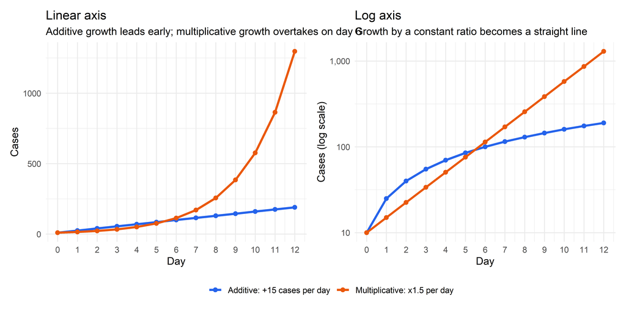

Figure 1: Figure 1. Additive growth (+15 cases per day) vs. multiplicative growth (×1.5 per day), shown on a linear axis and a log axis.

```r
growth_df <- tibble(day = 0:12) %>%
  mutate(
    Additive       = 10 + 15 * day,
    Multiplicative = 10 * 1.5^day
  ) %>%
  pivot_longer(-day, names_to = "process", values_to = "cases")

growth_colors <- c(Additive = col_blue, Multiplicative = col_orange)
growth_labels <- c(Additive = "Additive: +15 cases per day", Multiplicative = "Multiplicative: x1.5 per day")

p_growth_raw <- ggplot(growth_df, aes(day, cases, color = process)) +
  geom_line(linewidth = 1.2) +
  geom_point(size = 2) +
  scale_color_manual(values = growth_colors, labels = growth_labels) +
  scale_x_continuous(breaks = 0:12) +
  labs(title = "Linear axis",
       subtitle = "Additive growth leads early; multiplicative growth overtakes on day 6",
       x = "Day", y = "Cases", color = NULL)

p_growth_log <- ggplot(growth_df, aes(day, cases, color = process)) +
  geom_line(linewidth = 1.2) +
  geom_point(size = 2) +
  scale_color_manual(values = growth_colors, labels = growth_labels) +
  scale_y_log10(labels = comma) +
  scale_x_continuous(breaks = 0:12) +
  labs(title = "Log axis",
       subtitle = "Growth by a constant ratio becomes a straight line",
       x = "Day", y = "Cases (log scale)", color = NULL)

(p_growth_raw + p_growth_log) +
  plot_layout(guides = "collect") &
  theme(legend.position = "bottom")
```

Three things in Figure 1 are worth noticing:

1. **Early on, multiplicative growth looks harmless.** For the first five days the additive process is ahead. This is why exponential processes such as epidemics are often underestimated in their early stages.
2. **Later, multiplicative growth dominates.** By day 12 the multiplicative process has about seven times as many cases.
3. **On a log axis, the multiplicative process becomes a straight line.** A constant ratio per day becomes a constant *distance* per day. The additive process, meanwhile, bends downward on the log axis, because adding 15 to an ever larger number is a smaller and smaller proportional change.

The third point is the whole reason we use logarithms in regression. If a process grows by a constant ratio, taking the log turns it into a process that grows by a constant amount, and constant-amount change is exactly what a linear model describes.

**NoteThe roles of $e$, $\log$, and $\exp$ at a glance**

- **$e$ (Euler’s number, about 2.718)**: The base of continuous growth. It is what you get when growth compounds at every instant rather than at fixed intervals.
- **$\log(x)$**: Converts the multiplicative world into the additive world. Ratios become differences, and constant-ratio growth becomes a straight line.
- **$\exp(x)$**: Converts the additive world back into the multiplicative world. A regression coefficient on the log scale becomes a ratio (an odds ratio, a rate ratio, or a ratio of geometric means).

**TipNotation used in this post**

In this post, $\log$ always means the **natural logarithm** (base $e$), sometimes written $\ln$. In R, `log()` is the natural log and `log10()` is the base-10 log. In Stata, both `ln()` and `log()` are natural logs, and `log10()` is base 10. When a statistics textbook writes “log” without a base, it almost always means the natural log.

# 1. Historical Origins: Escaping Arithmetic Hell

### John Napier (1614): Turning multiplication into addition

In the early seventeenth century, astronomers and navigators spent much of their working lives on arithmetic. Computing a planetary position or a ship’s course meant multiplying and dividing long numbers by hand, and a single slip could ruin weeks of work.

In 1614 the Scottish mathematician **John Napier** published a solution. His idea was simple to state: multiplication is slow and error-prone, but addition is quick. If every number could be rewritten as a power of some fixed base, then multiplying two numbers would only require *adding* their exponents, because

$$A^m \times A^n = A^{m+n}.$$

The procedure works like this:

1. Look up each number in a table to find its exponent (its **logarithm**).
2. **Add** the two logarithms.
3. Look up the sum in the table in reverse to get the product.

```
[Multiplicative world]   123,456      x      789,101      (slow by hand)
                            |                    |
                         take log             take log
                            v                    v
[Additive world]         11.72364     +      13.57865   =  25.30229   (easy)
                                                          apply exp
                                                              v
[Back to the original scale]                           97,419,253,056
```

Napier coined the word **logarithm** from the Greek *logos* (ratio, proportion) and *arithmos* (number). A logarithm is, quite literally, a number that measures ratios.

A few historical clarifications are useful here, because popular accounts often blur them:

- **Napier’s original logarithms were not the natural logarithms we use today.** They were defined in a different way, for trigonometric calculation, and are only indirectly related to base $e$.
- **Henry Briggs**, an English mathematician who visited Napier, developed **base-10 (common) logarithms**. Briggs published his first tables in 1617, and base-10 tables became the everyday calculating tool of scientists and engineers for more than three centuries.
- The **slide rule** is a physical version of the same idea. Its scales are marked at distances proportional to logarithms, so sliding one scale along another adds two lengths, and adding lengths multiplies the numbers.

A remark often attributed to the French mathematician Pierre-Simon Laplace says that logarithms, by shortening the labor of calculation, doubled the life of the astronomer.

### Jacob Bernoulli (1683): The limit of continuous compounding

About seventy years later, the Swiss mathematician **Jacob Bernoulli** studied a question about compound interest. Suppose you deposit $1 at a nominal annual interest rate of 100%. How much do you have after one year?

- **Compounded once a year**: $\$1 \times (1 + 1)^1 = \$2.00$.
- **Compounded twice a year**: Each half-year pays 50%. After six months you have $1.50, and the second half-year pays 50% on $1.50, not on $1:
  $$\$1 \times \left(1 + \tfrac{1}{2}\right)^2 = \$2.25.$$
- **Compounded $n$ times a year**: $\$1 \times \left(1 + \tfrac{1}{n}\right)^n$.

Compounding more often always helps, because interest starts earning interest sooner. Bernoulli asked what happens if compounding becomes infinitely frequent. Does the balance grow without limit? Table 1 and Figure 2 show the answer.

```r
bern_table <- tibble(
  schedule = c("Annually", "Semiannually", "Quarterly", "Monthly",
               "Weekly", "Daily", "Hourly", "Every minute"),
  n = c(1, 2, 4, 12, 52, 365, 8760, 525600)
) %>%
  mutate(
    balance = (1 + 1 / n)^n,
    gap_from_e = exp(1) - balance
  )

bern_table %>%
  kbl(digits = c(0, 0, 6, 6),
      col.names = c("Compounding schedule", "n per year", "Balance after 1 year", "Gap from e"),
      format.args = list(big.mark = ","),
      caption = "Table 1. Growth of $1 at 100% annual interest under different compounding schedules") %>%
  kable_styling(bootstrap_options = c("striped", "hover", "condensed"), full_width = FALSE)
```

Table 1. Growth of $1 at 100% annual interest under different compounding schedules

| Compounding schedule | n per year | Balance after 1 year | Gap from e |
| --- | --- | --- | --- |
| Annually | 1 | 2.000000 | 0.718282 |
| Semiannually | 2 | 2.250000 | 0.468282 |
| Quarterly | 4 | 2.441406 | 0.276876 |
| Monthly | 12 | 2.613035 | 0.105247 |
| Weekly | 52 | 2.692597 | 0.025685 |
| Daily | 365 | 2.714567 | 0.003714 |
| Hourly | 8,760 | 2.718127 | 0.000155 |
| Every minute | 525,600 | 2.718279 | 0.000003 |

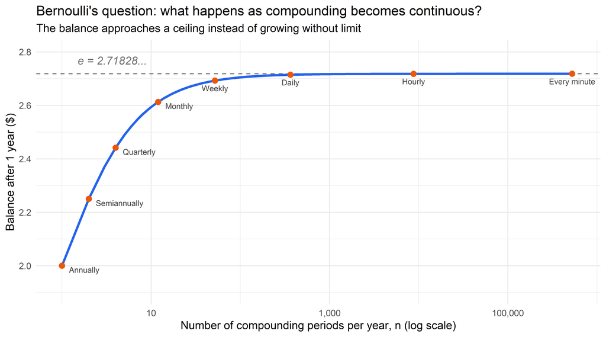

Figure 2: Figure 2. As compounding becomes more frequent, (1 + 1/n)^n rises but never passes e = 2.71828…

```r
bern_curve <- tibble(n = unique(round(10^seq(0, 5.75, length.out = 400)))) %>%
  mutate(balance = (1 + 1 / n)^n)

ggplot(bern_curve, aes(n, balance)) +
  geom_hline(yintercept = exp(1), linetype = "dashed", color = col_gray) +
  geom_line(color = col_blue, linewidth = 1.2) +
  geom_point(data = bern_table, color = col_orange, size = 2.5) +
  geom_text(data = filter(bern_table, n <= 12), aes(label = schedule),
            hjust = 0, nudge_x = 0.08, vjust = 1.2, size = 3, color = "gray25") +
  geom_text(data = filter(bern_table, n > 12), aes(label = schedule),
            vjust = 1.8, size = 3, color = "gray25") +
  annotate("text", x = 1.5, y = exp(1) + 0.05, label = "e = 2.71828...", hjust = 0, color = col_gray, fontface = "italic") +
  scale_x_log10(labels = comma) +
  coord_cartesian(ylim = c(1.9, 2.8)) +
  labs(title = "Bernoulli's question: what happens as compounding becomes continuous?",
       subtitle = "The balance approaches a ceiling instead of growing without limit",
       x = "Number of compounding periods per year, n (log scale)",
       y = "Balance after 1 year ($)")
```

The balance rises quickly at first and then levels off. No matter how often interest is compounded, it never passes a ceiling of about 2.71828:

$$\lim_{n \to \infty} \left(1 + \frac{1}{n}\right)^n = e = 2.718281828\dots$$

Bernoulli showed that the limit lies between 2 and 3. The letter $e$ for this constant came later, from **Leonhard Euler**, who used it in writings from the late 1720s onward. In his 1748 textbook *Introductio in analysin infinitorum*, Euler treated logarithms as exponents and connected $e$, the exponential function, and the natural logarithm in essentially the form we use today.

### From interest rates to growth rates

Bernoulli’s result generalizes. If a quantity grows at a nominal rate $r$ per unit of time, compounded $n$ times per unit, then after $t$ units it has been multiplied by $(1 + r/n)^{nt}$. As $n \to \infty$, this becomes

$$\left(1 + \frac{r}{n}\right)^{nt} \;\longrightarrow\; e^{rt}.$$

Here $r$ is called the **continuous growth rate**. This formula is the reason $e$ appears throughout population health. Cells divide, infections spread, and populations age continuously in time, not in yearly batches. When a process grows (or decays) at a rate proportional to its current size, its trajectory is $e^{rt}$, and its logarithm, $rt$, is a straight line in time.

# 2. Geometric Intuition: How $\exp$ and $\log$ Mirror Each Other

### Inverse functions

$\exp$ and $\log$ undo each other:

$$\log(\exp(x)) = x, \qquad \exp(\log(x)) = x \quad (x > 0).$$

A useful way to read $\log(x)$ is as the answer to a question: **“$e$ raised to what power gives $x$?”**

| Expression | Value | Meaning |
| --- | --- | --- |
| $\log(1)$ | $0$ | $e^0 = 1$. A ratio of 1 means no change. |
| $\log(e)$ | $1$ | $e^1 = e$. Multiplying by $e \approx 2.72$ is one log unit. |
| $\log(e^2)$ | $2$ | Multiplying by $e$ twice is two log units. |
| $\log(2)$ | $0.693$ | Doubling is about 0.69 log units. |
| $\log(0.5)$ | $-0.693$ | Halving is about $-0.69$ log units. |

The last two rows show something important. **On the log scale, doubling and halving are the same distance in opposite directions.** In general, the log of a ratio is positive for growth, negative for shrinkage, and zero for no change. This is why a coefficient of zero on the log scale corresponds to a ratio of one (an odds ratio of 1, a rate ratio of 1) on the original scale.

Figure 3 plots both functions.

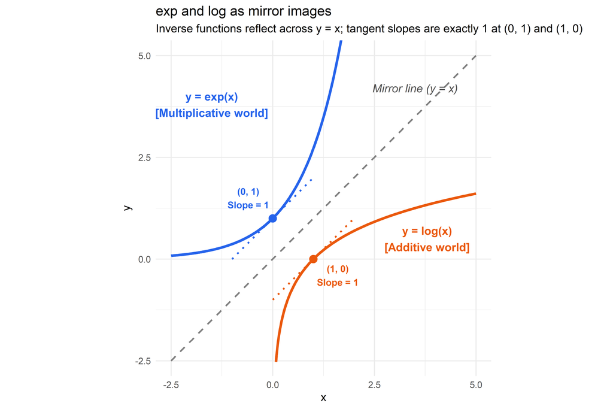

Figure 3. exp(x) and log(x) are mirror images across the line y = x. Both tangent slopes equal exactly 1 at the axis crossings.

```r
x_vals <- seq(-2.5, 2.5, length.out = 400)
x_pos  <- seq(0.08, 5.0, length.out = 400)

df_exp <- tibble(x = x_vals, y = exp(x_vals))
df_log <- tibble(x = x_pos, y = log(x_pos))
df_ref <- tibble(x = seq(-2.5, 5, length.out = 100), y = seq(-2.5, 5, length.out = 100))

tangent_exp <- tibble(x = seq(-1, 1, length.out = 50), y = x + 1)
tangent_log <- tibble(x = seq(0, 2, length.out = 50), y = x - 1)

ggplot() +
  geom_line(data = df_ref, aes(x = x, y = y), linetype = "dashed", color = "gray50", linewidth = 0.8) +
  geom_line(data = df_exp, aes(x = x, y = y), color = col_blue, linewidth = 1.3) +
  geom_line(data = df_log, aes(x = x, y = y), color = col_orange, linewidth = 1.3) +
  geom_line(data = tangent_exp, aes(x = x, y = y), color = col_blue, linetype = "dotted", linewidth = 0.9) +
  geom_line(data = tangent_log, aes(x = x, y = y), color = col_orange, linetype = "dotted", linewidth = 0.9) +
  geom_point(aes(x = 0, y = 1), color = col_blue, size = 3.5) +
  geom_point(aes(x = 1, y = 0), color = col_orange, size = 3.5) +
  annotate("text", x = -0.6, y = 1.5, label = "(0, 1)\nSlope = 1", color = col_blue, fontface = "bold", size = 3.5) +
  annotate("text", x = 1.6, y = -0.4, label = "(1, 0)\nSlope = 1", color = col_orange, fontface = "bold", size = 3.5) +
  annotate("text", x = -1.5, y = 3.8, label = "y = exp(x)\n[Multiplicative world]", color = col_blue, fontface = "bold") +
  annotate("text", x = 3.8, y = 0.5, label = "y = log(x)\n[Additive world]", color = col_orange, fontface = "bold") +
  annotate("text", x = 3.5, y = 4.2, label = "Mirror line (y = x)", color = "gray30", fontface = "italic") +
  coord_fixed(xlim = c(-2.5, 5), ylim = c(-2.5, 5)) +
  labs(
    title = "exp and log as mirror images",
    subtitle = "Inverse functions reflect across y = x; tangent slopes are exactly 1 at (0, 1) and (1, 0)",
    x = "x", y = "y"
  )
```

### Reading Figure 3

- **Blue curve, $y = \exp(x)$**: Each step to the right multiplies the height by the same factor ($e \approx 2.72$ per unit). The curve is always positive and rises faster and faster.
- **Orange curve, $y = \log(x)$**: Defined only for $x > 0$. It rises steeply near zero and then flattens: going from 1 to 10 adds 2.3 units, and going from 10 to 100 adds the same 2.3 units, even though the second step covers ten times more ground.
- **The mirror**: Fold the figure along the dashed line $y = x$ and the two curves land exactly on top of each other. Every point $(a, b)$ on the exp curve has a partner $(b, a)$ on the log curve. That is what it means to be inverse functions.

### Why is $e$ called the “natural” base?

Look at the dotted tangent lines. Where $y = \exp(x)$ crosses the y-axis at $(0, 1)$, its slope is exactly 1. Where $y = \log(x)$ crosses the x-axis at $(1, 0)$, its slope is also exactly 1. With base 10 or base 2, these slopes would be $\log(10) \approx 2.303$ or $\log(2) \approx 0.693$, and every formula in calculus would carry those constants around. Base $e$ is the only base for which the rate of change at the starting point is exactly 1, which keeps the formulas clean.

That slope of 1 has a practical payoff. Near $x = 0$, the exp curve and its tangent line $y = 1 + x$ are almost the same, so

$$\exp(x) \approx 1 + x \quad \text{and} \quad \log(1 + x) \approx x \quad \text{when } x \text{ is small.}$$

This approximation is the reason researchers can read small log-scale coefficients directly as percentages. We return to it in Section 3.

### Reading a log axis

Many figures in health research use a log axis, as in the right panel of Figure 1. Figure 4 shows how such an axis differs from an ordinary one.

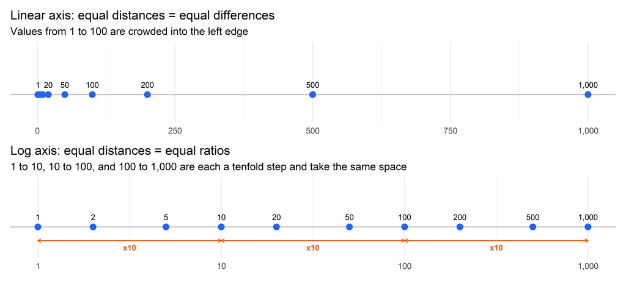

Figure 3: Figure 4. The same ten values on a linear axis and on a log axis. On a log axis, equal distances mean equal ratios.

```r
nl_df <- tibble(value = c(1, 2, 5, 10, 20, 50, 100, 200, 500, 1000))

number_line_theme <- theme(
  axis.text.y = element_blank(),
  panel.grid.major.y = element_blank(),
  panel.grid.minor.y = element_blank()
)

p_nl_lin <- ggplot(nl_df, aes(value, 0)) +
  geom_hline(yintercept = 0, color = "gray70") +
  geom_point(size = 3, color = col_blue) +
  geom_text(aes(label = comma(value)), vjust = -1.2, size = 3.2, check_overlap = TRUE) +
  scale_x_continuous(labels = comma, breaks = c(0, 250, 500, 750, 1000)) +
  coord_cartesian(ylim = c(-0.5, 1)) +
  labs(title = "Linear axis: equal distances = equal differences",
       subtitle = "Values from 1 to 100 are crowded into the left edge",
       x = NULL, y = NULL) +
  number_line_theme

ratio_marks <- tibble(x = c(1, 10, 100), xend = c(10, 100, 1000))

p_nl_log <- ggplot(nl_df, aes(value, 0)) +
  geom_hline(yintercept = 0, color = "gray70") +
  geom_segment(data = ratio_marks, aes(x = x, xend = xend, y = -0.3, yend = -0.3),
               inherit.aes = FALSE, color = col_orange,
               arrow = arrow(length = unit(0.15, "cm"), ends = "both")) +
  geom_text(data = ratio_marks, aes(x = sqrt(x * xend), y = -0.45, label = "x10"),
            inherit.aes = FALSE, color = col_orange, size = 3.2, fontface = "bold") +
  geom_point(size = 3, color = col_blue) +
  geom_text(aes(label = comma(value)), vjust = -1.2, size = 3.2) +
  scale_x_log10(labels = comma, breaks = c(1, 10, 100, 1000)) +
  coord_cartesian(ylim = c(-0.6, 1)) +
  labs(title = "Log axis: equal distances = equal ratios",
       subtitle = "1 to 10, 10 to 100, and 100 to 1,000 are each a tenfold step and take the same space",
       x = NULL, y = NULL) +
  number_line_theme

p_nl_lin / p_nl_log
```

Three rules make log axes easy to read:

1. **Equal distances mean equal ratios.** Moving from 1 to 10 takes the same space as moving from 100 to 1,000.
2. **Parallel lines mean a constant ratio.** If two groups’ lines run parallel on a log axis, one group’s values are a fixed multiple of the other’s at every point. We will see this with healthcare spending in Figure 12.
3. **The base does not change the shape.** Base-10 and natural logs differ only by a constant factor, $\log_{10}(x) = \log(x) / \log(10)$. A ggplot axis made with `scale_y_log10()` has the same shape as one made with natural logs; only the tick labels differ.

### The rules of logarithms and where they appear in research

Every use of logs in this post rests on a handful of rules.

| Rule | Formula | Where it appears in research |
| --- | --- | --- |
| Product becomes sum | $\log(ab) = \log a + \log b$ | Multiplicative effects in the outcome become additive coefficients in the model. |
| Quotient becomes difference | $\log(a/b) = \log a - \log b$ | A difference in log outcomes is the log of a ratio. Log rate ratios and log odds ratios are differences on the log scale. |
| Power becomes product | $\log(a^k) = k \log a$ | A 10-year age difference with a per-year coefficient $\beta$ is $10\beta$ on the log scale, or $\exp(\beta)^{10}$ on the ratio scale. |
| Log of 1 is 0 | $\log 1 = 0$ | A coefficient of 0 means a ratio of 1 (no effect). A confidence interval for a ratio is checked against 1, not 0. |
| Defined only for positive numbers | $\log x$ requires $x > 0$ | Outcomes with zeros (no doctor visits, no spending) need special care. See Section 4. |

# 3. Companion Concepts for Health Research

### A running example

To keep the examples connected, the rest of this post uses one simulated health survey of 2,000 adults. The simulation is built so that we know the true values and can check whether our models recover them.

- **Age**: uniform between 25 and 80.
- **Income**: log-normal, so it is right-skewed like real income data.
- **Health insurance**: 85% insured.
- **Chronic disease**: generated from a logistic model in which the log-odds rise with age, fall with log income, and fall with insurance.
- **Annual healthcare spending**: generated on the log scale, so spending rises by a constant *percentage* with each year of age and is a constant *multiple* higher for people with a chronic condition.

```r
set.seed(2026)
n <- 2000

age           <- round(runif(n, 25, 80))
income        <- round(rlnorm(n, meanlog = 10.5, sdlog = 0.6))
has_insurance <- rbinom(n, 1, prob = 0.85)

# True model for chronic disease (log-odds scale)
log_odds_chronic    <- -4.2 + 0.055 * age - 0.45 * log(income / 1000) - 0.3 * has_insurance
prob_chronic        <- exp(log_odds_chronic) / (1 + exp(log_odds_chronic))
has_chronic_disease <- rbinom(n, 1, prob = prob_chronic)

# True model for spending (log scale)
log_spending    <- 5.2 + 0.03 * age + 0.85 * has_chronic_disease + rnorm(n, 0, 0.55)
annual_spending <- round(exp(log_spending), 2)

health_df <- tibble(
  id              = 1:n,
  age             = age,
  income          = income,
  has_insurance   = has_insurance,
  has_chronic     = has_chronic_disease,
  annual_spending = annual_spending
)

health_df %>%
  head(6) %>%
  kbl(caption = "Table 2. First six rows of the simulated health survey",
      format.args = list(big.mark = ",")) %>%
  kable_styling(bootstrap_options = c("striped", "hover", "condensed"), full_width = FALSE)
```

Table 2. First six rows of the simulated health survey

| id | age | income | has_insurance | has_chronic | annual_spending |
| --- | --- | --- | --- | --- | --- |
| 1 | 63 | 105,065 | 1 | 0 | 2,112.70 |
| 2 | 56 | 62,332 | 1 | 0 | 1,573.89 |
| 3 | 33 | 80,680 | 1 | 0 | 672.09 |
| 4 | 41 | 29,449 | 1 | 0 | 767.04 |
| 5 | 56 | 68,687 | 0 | 1 | 1,081.89 |
| 6 | 26 | 25,035 | 1 | 0 | 306.22 |

```r
spend_am  <- mean(health_df$annual_spending)
spend_med <- median(health_df$annual_spending)
spend_gm  <- exp(mean(log(health_df$annual_spending)))
```

### 3.1 The geometric mean: $\exp(\text{mean}(\log X))$

Suppose three patients spend $100, $1,000, and $10,000 on healthcare in a year. The ordinary (arithmetic) mean is $3,700, which is higher than what two of the three patients spent. The **geometric mean** is

$$\sqrt[3]{100 \times 1{,}000 \times 10{,}000} = \sqrt[3]{10^9} = 1{,}000,$$

which sits in the middle of the three values *in ratio terms*: $1,000 is ten times $100, and $10,000 is ten times $1,000.

In general,

$$\text{Geometric mean} = \sqrt[n]{x_1 \times x_2 \times \dots \times x_n} = \exp\left( \frac{1}{n} \sum_{i=1}^n \log(x_i) \right).$$

The right-hand side describes a three-step recipe that should look familiar from Napier: take the log of every value, compute the ordinary average of the logs, and exponentiate back to the original units. In other words, **the geometric mean is the arithmetic mean computed in the additive world and translated back.**

Some properties worth knowing:

- The geometric mean is never larger than the arithmetic mean. They are equal only when all values are identical.
- For log-normal data, the geometric mean is close to the median.
- It is the natural summary for quantities that vary by multiples, such as antibody titers (reported as geometric mean titers), environmental exposure concentrations, and healthcare costs.

Figure 5 shows the three summaries for spending in our simulated survey. The arithmetic mean is $1,282, the median is $908, and the geometric mean is $929.

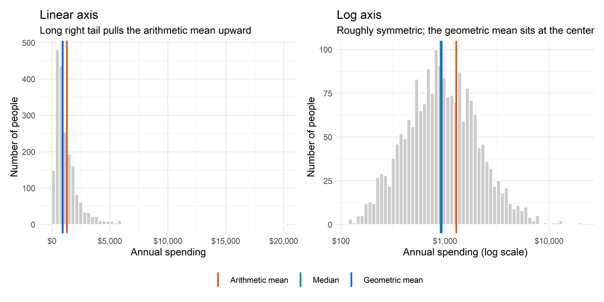

Figure 4: Figure 5. Distribution of simulated annual healthcare spending on a linear axis and a log axis, with three summary statistics.

```r
stat_lines <- tibble(
  stat  = factor(c("Arithmetic mean", "Median", "Geometric mean"),
                 levels = c("Arithmetic mean", "Median", "Geometric mean")),
  value = c(spend_am, spend_med, spend_gm)
)
stat_colors <- c("Arithmetic mean" = col_orange, "Median" = col_green, "Geometric mean" = col_blue)

p_gm_raw <- ggplot(health_df, aes(annual_spending)) +
  geom_histogram(bins = 60, fill = "gray80", color = "white") +
  geom_vline(data = stat_lines, aes(xintercept = value, color = stat), linewidth = 1) +
  scale_x_continuous(labels = dollar) +
  scale_color_manual(values = stat_colors) +
  labs(title = "Linear axis", subtitle = "Long right tail pulls the arithmetic mean upward",
       x = "Annual spending", y = "Number of people", color = NULL)

p_gm_log <- ggplot(health_df, aes(annual_spending)) +
  geom_histogram(bins = 60, fill = "gray80", color = "white") +
  geom_vline(data = stat_lines, aes(xintercept = value, color = stat), linewidth = 1) +
  scale_x_log10(labels = dollar) +
  scale_color_manual(values = stat_colors) +
  labs(title = "Log axis", subtitle = "Roughly symmetric; the geometric mean sits at the center",
       x = "Annual spending (log scale)", y = "Number of people", color = NULL)

(p_gm_raw + p_gm_log) +
  plot_layout(guides = "collect") &
  theme(legend.position = "bottom")
```

On the linear axis, a small number of very high spenders stretch the distribution to the right and pull the arithmetic mean above the median. On the log axis, the distribution is close to symmetric, and the geometric mean falls near its center.

**WarningThe geometric mean does not replace the arithmetic mean**

If the question is about totals, such as a hospital budget or the total cost of a program, the arithmetic mean is the right quantity, because total cost equals the number of people times the arithmetic mean. The geometric mean describes a *typical* person on the ratio scale; it does not add up to the total. This distinction returns in Section 4, where it becomes the *retransformation problem*.

### 3.2 The small-change approximation: reading $\beta$ as a percentage

Suppose you fit a model with a logged outcome, $\log(Y) = \beta_0 + \beta_1 X$. A one-unit increase in $X$ adds $\beta_1$ to $\log(Y)$, which means $Y$ is *multiplied* by $\exp(\beta_1)$. The exact percentage change is therefore

$$\text{Exact percentage change} = \left(\exp(\beta_1) - 1\right) \times 100\%.$$

Section 2 showed that $\exp(x) \approx 1 + x$ near zero. So when $\beta_1$ is small,

$$\left(\exp(\beta_1) - 1\right) \times 100\% \approx \beta_1 \times 100\%.$$

That is why papers often say “a coefficient of 0.03 means about a 3% increase.” Figure 6 shows how far this shortcut can be trusted.

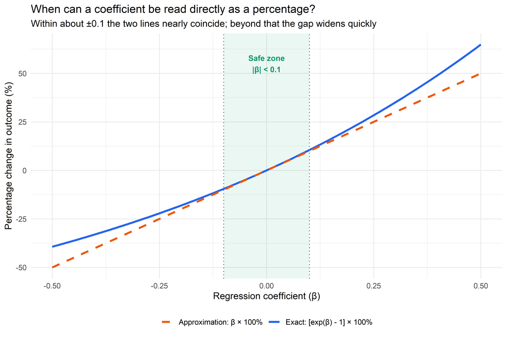

Figure 6. The exact percentage change [exp(β) - 1] × 100% vs. the approximation β × 100%.

```r
approx_df <- tibble(
  beta       = seq(-0.5, 0.5, length.out = 200),
  exact_pct  = (exp(beta) - 1) * 100,
  approx_pct = beta * 100
)

ggplot(approx_df, aes(x = beta)) +
  annotate("rect", xmin = -0.1, xmax = 0.1, ymin = -Inf, ymax = Inf, alpha = 0.08, fill = col_green) +
  geom_line(aes(y = exact_pct, color = "Exact: [exp(β) - 1] × 100%"), linewidth = 1.2) +
  geom_line(aes(y = approx_pct, color = "Approximation: β × 100%"), linetype = "dashed", linewidth = 1.2) +
  scale_color_manual(values = c("Exact: [exp(β) - 1] × 100%" = col_blue, "Approximation: β × 100%" = col_orange)) +
  geom_vline(xintercept = c(-0.1, 0.1), linetype = "dotted", color = "gray40") +
  annotate("text", x = 0, y = 55, label = "Safe zone\n|β| < 0.1", color = col_green, fontface = "bold", size = 3.5) +
  labs(
    title = "When can a coefficient be read directly as a percentage?",
    subtitle = "Within about ±0.1 the two lines nearly coincide; beyond that the gap widens quickly",
    x = "Regression coefficient (β)",
    y = "Percentage change in outcome (%)",
    color = NULL
  ) +
  theme(legend.position = "bottom")
```

```r
tibble(beta = c(-0.5, -0.2, -0.1, -0.05, 0.05, 0.1, 0.2, 0.5, 1.0)) %>%
  mutate(
    approx_pct = beta * 100,
    exact_pct  = (exp(beta) - 1) * 100,
    error_pp   = approx_pct - exact_pct
  ) %>%
  kbl(digits = c(2, 1, 1, 1),
      col.names = c("Coefficient β", "Approximation (%)", "Exact (%)", "Error (percentage points)"),
      caption = "Table 3. How large is the error of the β × 100% shortcut?") %>%
  kable_styling(bootstrap_options = c("striped", "hover", "condensed"), full_width = FALSE)
```

Table 3. How large is the error of the β × 100% shortcut?

| Coefficient β | Approximation (%) | Exact (%) | Error (percentage points) |
| --- | --- | --- | --- |
| -0.50 | -50 | -39.3 | -10.7 |
| -0.20 | -20 | -18.1 | -1.9 |
| -0.10 | -10 | -9.5 | -0.5 |
| -0.05 | -5 | -4.9 | -0.1 |
| 0.05 | 5 | 5.1 | -0.1 |
| 0.10 | 10 | 10.5 | -0.5 |
| 0.20 | 20 | 22.1 | -2.1 |
| 0.50 | 50 | 64.9 | -14.9 |
| 1.00 | 100 | 171.8 | -71.8 |

Table 3 suggests a practical rule: **if $|\beta| < 0.1$, reading $\beta \times 100$ as a percentage is fine; otherwise compute $\exp(\beta) - 1$.** Two patterns stand out:

- **The approximation always understates increases and overstates decreases.** A coefficient of 0.5 is not a 50% increase but a 65% increase. A coefficient of $-0.5$ is not a 50% decrease but a 39% decrease.
- **The error grows fast.** At $\beta = 1$, the shortcut says 100% while the truth is 172%.

There is also a reason to like log units on their own terms. On the percentage scale, going from 100 to 200 is $+100\%$, but going back from 200 to 100 is $-50\%$. On the log scale, the two moves are $+0.693$ and $-0.693$: symmetric, and they add up to zero. Economists sometimes call a difference of 0.01 in logs “one log point” for this reason.

### 3.3 Doubling time and the “rule of 70”

If something grows continuously at rate $r$ per day, it has been multiplied by $e^{rt}$ after $t$ days. Setting $e^{rt} = 2$ and solving for $t$:

$$t_{\text{double}} = \frac{\log 2}{r} \approx \frac{0.693}{r} \approx \frac{70}{\text{growth rate in percent}}.$$

The 70 in the “rule of 70” is $100 \times \log 2 \approx 69.3$, rounded for convenience. If infections grow by 7% per day, they double in about $70 / 7 = 10$ days.

The same logic gives the **half-life** of anything that decays at a constant proportional rate $k$, such as a drug being cleared from the bloodstream: $t_{1/2} = \log 2 / k$.

One subtlety: the rule of 70 is exact for *continuous* growth. If growth is compounded once per day, the exact doubling time is $\log 2 / \log(1 + r)$, which is slightly longer. Table 4 compares the three calculations.

```r
tibble(r = c(0.01, 0.02, 0.05, 0.07, 0.10, 0.20)) %>%
  mutate(
    pct        = r * 100,
    rule_70    = 70 / pct,
    continuous = log(2) / r,
    discrete   = log(2) / log(1 + r)
  ) %>%
  select(-r) %>%
  kbl(digits = 1,
      col.names = c("Daily growth rate (%)", "Rule of 70", "Exact, continuous: log(2)/r",
                    "Exact, once-daily compounding: log(2)/log(1 + r)"),
      caption = "Table 4. Doubling time in days under three calculations") %>%
  kable_styling(bootstrap_options = c("striped", "hover", "condensed"), full_width = FALSE)
```

Table 4. Doubling time in days under three calculations

| Daily growth rate (%) | Rule of 70 | Exact, continuous: log(2)/r | Exact, once-daily compounding: log(2)/log(1 + r) |
| --- | --- | --- | --- |
| 1 | 70.0 | 69.3 | 69.7 |
| 2 | 35.0 | 34.7 | 35.0 |
| 5 | 14.0 | 13.9 | 14.2 |
| 7 | 10.0 | 9.9 | 10.2 |
| 10 | 7.0 | 6.9 | 7.3 |
| 20 | 3.5 | 3.5 | 3.8 |

For small growth rates the three columns are nearly identical. At high growth rates, such as 20% per day, the rule of 70 and the continuous formula understate the doubling time under once-daily compounding by about 9%. (The “rule of 72,” often quoted in finance, is a slightly better fit for annual compounding at moderate interest rates.)

### 3.4 The function that is its own derivative, and the Gompertz law of mortality

The exponential function has a special property:

$$\frac{d}{dx} \exp(x) = \exp(x).$$

At every point, the slope of the curve equals its height. To be precise, any function of the form $c \cdot e^x$ has this property, and $e^x$ is the unique one with $f(0) = 1$.

More generally, if a quantity changes at a rate proportional to its current size, $f'(x) = b\, f(x)$, then the quantity must follow $f(x) = a \cdot e^{bx}$. This is the mathematical form of “the bigger it is, the faster it grows.”

In 1825 the British actuary **Benjamin Gompertz** proposed that adult mortality follows exactly this pattern. The **Gompertz law** says that the hazard of death at age $x$ is

$$h(x) = a \cdot e^{bx}, \qquad \log h(x) = \log a + b\,x.$$

On the original scale, mortality curves upward steeply with age. On the log scale, it is a straight line with slope $b$. In many human populations, adult mortality roughly doubles every 7 to 8 years, which corresponds to $b \approx \log 2 / 8 \approx 0.087$ per year. Figure 7 draws this pattern with illustrative parameters.

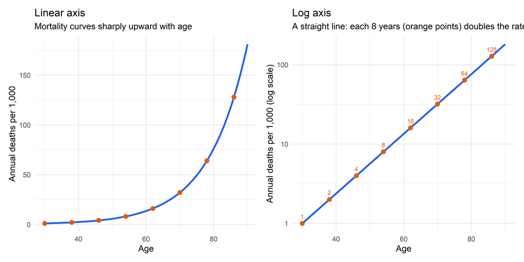

Figure 5: Figure 7. An illustrative Gompertz mortality curve (death rate doubling every 8 years from 1 per 1,000 at age 30) on a linear axis and a log axis. Parameters are illustrative, not estimates for a specific population.

```r
b_gomp <- log(2) / 8

gomp_df <- tibble(age = 30:90) %>%
  mutate(rate_per_1000 = 1 * exp(b_gomp * (age - 30)))

gomp_marks <- tibble(age = seq(30, 86, by = 8)) %>%
  mutate(rate_per_1000 = 1 * exp(b_gomp * (age - 30)))

p_gomp_raw <- ggplot(gomp_df, aes(age, rate_per_1000)) +
  geom_line(color = col_blue, linewidth = 1.2) +
  geom_point(data = gomp_marks, color = col_orange, size = 2.5) +
  labs(title = "Linear axis", subtitle = "Mortality curves sharply upward with age",
       x = "Age", y = "Annual deaths per 1,000")

p_gomp_log <- ggplot(gomp_df, aes(age, rate_per_1000)) +
  geom_line(color = col_blue, linewidth = 1.2) +
  geom_point(data = gomp_marks, color = col_orange, size = 2.5) +
  geom_text(data = gomp_marks, aes(label = comma(rate_per_1000, accuracy = 1)),
            vjust = -1, size = 3, color = col_orange) +
  scale_y_log10(labels = comma) +
  labs(title = "Log axis", subtitle = "A straight line: each 8 years (orange points) doubles the rate",
       x = "Age", y = "Annual deaths per 1,000 (log scale)")

p_gomp_raw + p_gomp_log
```

The Gompertz pattern explains why so many models in health research use a log link. In a Poisson regression of death counts or a Cox proportional hazards model, the coefficient on age is the slope $b$ in Figure 7’s right panel, and $\exp(b)$ is the **rate ratio** or **hazard ratio** per year of age. The Gompertz law fits adult ages well; it does not describe childhood mortality, and at the very oldest ages the increase in mortality tends to slow down.

# 4. Three Classic Health Sociology Scenarios

### Scenario A: The Preston curve and diminishing returns

In 1975 the demographer **Samuel Preston** described the cross-national relationship between national income and life expectancy. Among poor countries, small increases in income go with large gains in life expectancy. Among rich countries, the same dollar increase goes with almost no gain. The curve rises steeply and then flattens.

Figure 8 reproduces this shape with simulated country data. The left panel uses GDP per capita in dollars; the right panel uses the log of GDP per capita.

```r
set.seed(101)
n_countries <- 150

gdp_per_capita <- round(rlnorm(n_countries, meanlog = 9, sdlog = 1.1))
gdp_per_capita <- pmax(500, pmin(85000, gdp_per_capita))

life_expectancy <- 38 + 4.2 * log(gdp_per_capita) + rnorm(n_countries, 0, 2.5)
life_expectancy <- pmin(85, pmax(45, life_expectancy))

preston_data <- tibble(
  country_id = 1:n_countries,
  gdp_pc     = gdp_per_capita,
  log_gdp    = log(gdp_per_capita),
  life_exp   = round(life_expectancy, 1)
)

preston_lm <- lm(life_exp ~ log_gdp, data = preston_data)
b_preston  <- unname(coef(preston_lm)["log_gdp"])
```

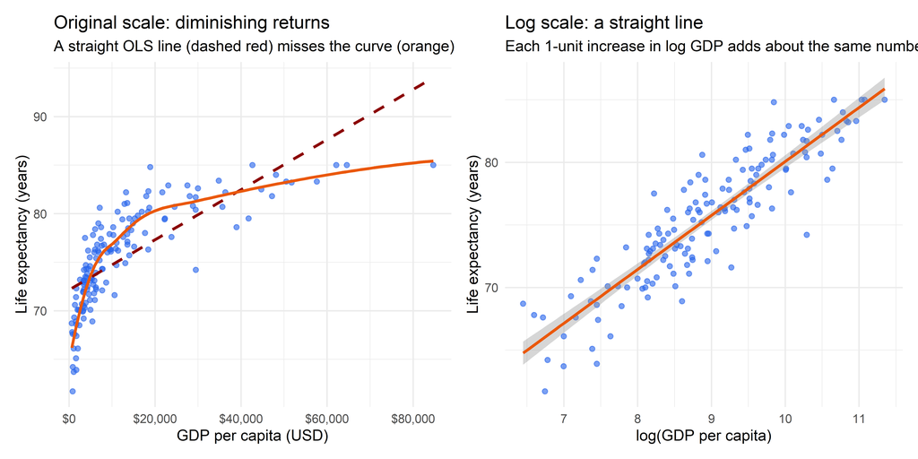

Figure 8. Simulated data: GDP per capita and life expectancy on the original scale (left) and with GDP logged (right).

```r
p1 <- ggplot(preston_data, aes(x = gdp_pc, y = life_exp)) +
  geom_point(alpha = 0.6, color = col_blue) +
  geom_smooth(method = "lm", color = "darkred", se = FALSE, linetype = "dashed") +
  geom_smooth(method = "loess", color = col_orange, se = FALSE) +
  scale_x_continuous(labels = dollar_format()) +
  labs(
    title = "Original scale: diminishing returns",
    subtitle = "A straight OLS line (dashed red) misses the curve (orange)",
    x = "GDP per capita (USD)",
    y = "Life expectancy (years)"
  )

p2 <- ggplot(preston_data, aes(x = log_gdp, y = life_exp)) +
  geom_point(alpha = 0.6, color = col_blue) +
  geom_smooth(method = "lm", color = col_orange, se = TRUE) +
  labs(
    title = "Log scale: a straight line",
    subtitle = "Each 1-unit increase in log GDP adds about the same number of years",
    x = "log(GDP per capita)",
    y = "Life expectancy (years)"
  )

p1 + p2
```

The fitted model is $\widehat{\text{life expectancy}} = \hat\beta_0 + 4.31 \times \log(\text{GDP})$. How should we read the slope of 4.31?

- **Per log unit**: A one-unit increase in $\log(\text{GDP})$ means GDP is multiplied by $e \approx 2.72$. Such an increase goes with about 4.31 more years of life expectancy.
- **Per doubling**: Doubling GDP adds $\log 2 = 0.693$ to $\log(\text{GDP})$, so the predicted gain is $4.31 \times 0.693 = 2.99$ years, *whether the country starts at $1,000 or $40,000*.
- **Per 10% increase**: $4.31 \times \log(1.1) = 0.41$ years.

Table 5 makes the diminishing returns explicit.

```r
tibble(
  scenario = c("Poor country: $1,000 to $2,000",
               "Rich country: $40,000 to $41,000",
               "Rich country: $40,000 to $80,000"),
  from = c(1000, 40000, 40000),
  to   = c(2000, 41000, 80000)
) %>%
  mutate(
    abs_increase = to - from,
    ratio        = to / from,
    gain_years   = b_preston * log(to / from)
  ) %>%
  select(scenario, abs_increase, ratio, gain_years) %>%
  kbl(digits = c(0, 0, 3, 2),
      col.names = c("Scenario", "Absolute increase ($)", "Ratio (to / from)", "Predicted gain (years)"),
      format.args = list(big.mark = ","),
      caption = "Table 5. Predicted life expectancy gains from the log-GDP model") %>%
  kable_styling(bootstrap_options = c("striped", "hover", "condensed"), full_width = FALSE)
```

Table 5. Predicted life expectancy gains from the log-GDP model

| Scenario | Absolute increase ($) | Ratio (to / from) | Predicted gain (years) |
| --- | --- | --- | --- |
| Poor country: $1,000 to $2,000 | 1,000 | 2.000 | 2.99 |
| Rich country: $40,000 to $41,000 | 1,000 | 1.025 | 0.11 |
| Rich country: $40,000 to $80,000 | 40,000 | 2.000 | 2.99 |

The same $1,000 increase is worth 2.99 years in the poor country and only 0.11 years in the rich one. A doubling, by contrast, is worth the same 2.99 years in both. This is what it means to say the effect of income is **proportional**: the log model assumes that equal *ratios* have equal effects.

The data here are simulated. Preston’s own study made a further point: the whole curve shifted upward between the 1930s and the 1960s, so at any given income level, countries in the later period had higher life expectancy. He concluded that income growth explained only a modest share of the gains in life expectancy, with much of the rest attributable to other factors such as public health measures and medical technology.

### Scenario B: Why logistic regression relies on $\log$ and $\exp$

Many health outcomes are binary: diagnosed or not, screened or not, died or survived. We want to model the probability $p$ of the outcome. A linear model $p = \beta_0 + \beta_1 X$ has an obvious problem: probabilities must lie between 0 and 1, but a straight line keeps going and can predict a probability of $-0.3$ or $1.2$.

Logistic regression solves this with two transformations, each of which removes one boundary.

**Step 1: From probability to odds.** The odds are the probability that the event happens divided by the probability that it does not:

$$\text{Odds} = \frac{p}{1 - p}.$$

Odds are familiar from betting. A probability of 0.8 means the event happens 80 times for every 20 times it does not, so the odds are $0.8 / 0.2 = 4$, or “4 to 1.” Odds range from 0 to $+\infty$, which removes the upper boundary of 1.

**Step 2: From odds to log-odds.** Taking the log of the odds removes the lower boundary of 0:

$$\text{logit}(p) = \log\left(\frac{p}{1 - p}\right), \qquad -\infty < \text{logit}(p) < +\infty.$$

Now the outcome can take any real value, and a linear predictor fits naturally:

$$\log\left(\frac{p}{1 - p}\right) = \beta_0 + \beta_1 X.$$

Table 6 shows how the three scales line up.

```r
tibble(p = c(0.01, 0.05, 0.10, 0.20, 0.50, 0.80, 0.90, 0.95, 0.99)) %>%
  mutate(odds = p / (1 - p), logit = log(odds)) %>%
  kbl(digits = 3,
      col.names = c("Probability p", "Odds p / (1 - p)", "Log-odds log(odds)"),
      caption = "Table 6. Probability, odds, and log-odds side by side") %>%
  kable_styling(bootstrap_options = c("striped", "hover", "condensed"), full_width = FALSE)
```

Table 6. Probability, odds, and log-odds side by side

| Probability p | Odds p / (1 - p) | Log-odds log(odds) |
| --- | --- | --- |
| 0.01 | 0.010 | -4.595 |
| 0.05 | 0.053 | -2.944 |
| 0.10 | 0.111 | -2.197 |
| 0.20 | 0.250 | -1.386 |
| 0.50 | 1.000 | 0.000 |
| 0.80 | 4.000 | 1.386 |
| 0.90 | 9.000 | 2.197 |
| 0.95 | 19.000 | 2.944 |
| 0.99 | 99.000 | 4.595 |

Notice the symmetry in Table 6. A probability of 0.5 corresponds to odds of 1 and log-odds of 0. Probabilities of 0.2 and 0.8 have log-odds of $-1.386$ and $+1.386$. The log-odds scale treats “unlikely” and “likely” as mirror images, just as the log scale treated halving and doubling.

**Where the odds ratio comes from.** Compare two people whose $X$ differs by one unit. Their log-odds differ by $\beta_1$:

$$\log(\text{Odds}_{X+1}) - \log(\text{Odds}_X) = \beta_1.$$

By the quotient rule, the left side is the log of a ratio, so

$$\log\left(\frac{\text{Odds}_{X+1}}{\text{Odds}_X}\right) = \beta_1 \quad\Longrightarrow\quad \frac{\text{Odds}_{X+1}}{\text{Odds}_X} = \exp(\beta_1).$$

**$\exp(\beta_1)$ is the odds ratio (OR).** It tells us by what factor the odds are multiplied for a one-unit increase in $X$, and it is the same factor at every value of $X$.

**But the odds ratio is not a change in probability.** Because the S-shaped curve is steep in the middle and flat at the ends, the same step on the log-odds scale produces very different changes in probability depending on where you start. Figure 9 shows this.

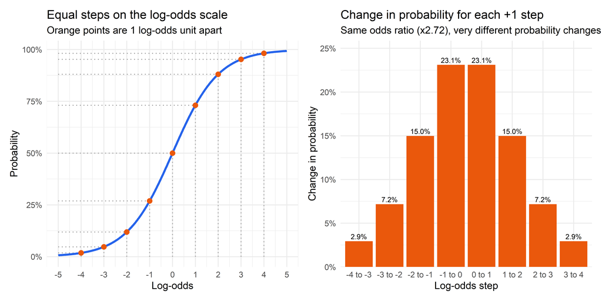

Figure 6: Figure 9. Equal steps on the log-odds scale (each step multiplies the odds by e ≈ 2.72) produce unequal changes in probability.

```r
s_curve <- tibble(z = seq(-5, 5, length.out = 400), p = plogis(z))
steps   <- tibble(z = -4:4, p = plogis(z))
step_change <- tibble(from = -4:3, to = -3:4) %>%
  mutate(dp = plogis(to) - plogis(from),
         label = paste0(from, " to ", to))

p_s <- ggplot(s_curve, aes(z, p)) +
  geom_segment(data = steps, aes(x = z, xend = z, y = 0, yend = p), linetype = "dotted", color = "gray60") +
  geom_segment(data = steps, aes(x = -5, xend = z, y = p, yend = p), linetype = "dotted", color = "gray60") +
  geom_line(color = col_blue, linewidth = 1.2) +
  geom_point(data = steps, color = col_orange, size = 2.5) +
  scale_x_continuous(breaks = -5:5) +
  scale_y_continuous(labels = percent) +
  labs(title = "Equal steps on the log-odds scale",
       subtitle = "Orange points are 1 log-odds unit apart",
       x = "Log-odds", y = "Probability")

p_bar <- ggplot(step_change, aes(factor(label, levels = label), dp)) +
  geom_col(fill = col_orange) +
  geom_text(aes(label = percent(dp, accuracy = 0.1)), vjust = -0.4, size = 3) +
  scale_y_continuous(labels = percent, expand = expansion(mult = c(0, 0.12))) +
  labs(title = "Change in probability for each +1 step",
       subtitle = "Same odds ratio (x2.72), very different probability changes",
       x = "Log-odds step", y = "Change in probability")

p_s + p_bar
```

Every bar in the right panel corresponds to the same odds ratio of $e \approx 2.72$. Yet moving from log-odds 0 to 1 raises the probability by about 23 percentage points, while moving from $-4$ to $-3$ raises it by only about 3 points. **An odds ratio has no single translation into a change in probability; the translation depends on the baseline.** We return to this point in Sections 5 and 7.

### Scenario C: Two pitfalls of log transformation

Logs are powerful, but two problems come up again and again in health data.

#### Pitfall 1: Zeros

The log of zero is undefined, and many health outcomes have zeros: people who had no doctor visits or no healthcare spending in a year. A common workaround is to analyze $\log(Y + 1)$. The trouble is that the result depends on the units of $Y$. Adding 1 *dollar* and adding 1 *cent* are very different changes when the rest of the data are measured in hundreds of dollars.

To see this, we take our simulated spending data and set spending to zero for a random subset of people (30% of those without a chronic condition and 5% of those with one). We then estimate the spending gap between people with and without a chronic condition, measuring spending in cents, dollars, and thousands of dollars.

```r
set.seed(7)
zero_df <- health_df %>%
  mutate(
    any_use = rbinom(n(), 1, prob = ifelse(has_chronic == 1, 0.95, 0.70)),
    spend_z = annual_spending * any_use
  )

share_zero <- mean(zero_df$spend_z == 0)

unit_results <- tibble(
  unit  = c("Cents", "Dollars", "Thousands of dollars"),
  scale = c(100, 1, 1 / 1000)
) %>%
  mutate(
    log1p_coef = map_dbl(scale, ~ coef(lm(log(spend_z * .x + 1) ~ has_chronic, data = zero_df))[["has_chronic"]]),
    glm_coef   = map_dbl(scale, ~ coef(glm(I(spend_z * .x) ~ has_chronic,
                                           family = quasipoisson(link = "log"),
                                           data = zero_df))[["has_chronic"]])
  )

unit_results %>%
  transmute(
    unit,
    log1p_coef,
    log1p_pct = (exp(log1p_coef) - 1) * 100,
    glm_coef,
    glm_ratio = exp(glm_coef)
  ) %>%
  kbl(digits = c(0, 3, 1, 3, 3),
      col.names = c("Spending measured in", "OLS on log(y + 1): coefficient", "Implied % difference",
                    "Log-link GLM: coefficient", "Ratio of means, exp(β)"),
      caption = "Table 7. The chronic-disease spending gap estimated with log(y + 1) and with a log-link GLM, under three units of measurement") %>%
  kable_styling(bootstrap_options = c("striped", "hover", "condensed"), full_width = FALSE)
```

Table 7. The chronic-disease spending gap estimated with log(y + 1) and with a log-link GLM, under three units of measurement

| Spending measured in | OLS on log(y + 1): coefficient | Implied % difference | Log-link GLM: coefficient | Ratio of means, exp(β) |
| --- | --- | --- | --- | --- |
| Cents | 3.844 | 4572.4 | 1.369 | 3.933 |
| Dollars | 2.701 | 1389.0 | 1.369 | 3.933 |
| Thousands of dollars | 0.770 | 116.0 | 1.369 | 3.933 |

About 29% of people now have zero spending. The $\log(Y + 1)$ estimates in Table 7 change dramatically with the unit of measurement, even though the data are the same. The model is not answering a stable question: with many zeros, its coefficient mixes the difference in *whether* people spend anything with the difference in *how much* they spend, and the weight on each depends on the arbitrary unit. By contrast, the log-link GLM gives the same answer in every unit, because it models $\log E[Y]$ rather than $E[\log(Y + 1)]$, and zeros pose no problem for a mean.

Common alternatives when an outcome has many zeros:

- **A GLM with a log link** (Poisson, quasi-Poisson, or gamma family). It models the log of the *mean*, so $\exp(\beta)$ is a ratio of means.
- **A two-part model.** The first part models whether $Y > 0$ (for example, with logistic regression); the second part models the amount among those with $Y > 0$. This approach is widely used in health economics.
- **Thinking about the question first.** If what matters is the share of people who use any care, model that directly.

#### Pitfall 2: Retransformation bias

Suppose we fit a log-linear model of spending, $\log(Y) = \beta_0 + \beta_1 \text{Age} + \beta_2 \text{Chronic} + \varepsilon$, and want to predict *average* spending in dollars. The natural move is to exponentiate the predicted log value. This gives the wrong answer, because

$$\exp\big(E[\log Y]\big) \neq E[Y].$$

The left side is the geometric mean from Section 3.1; the right side is the arithmetic mean. Since the geometric mean is always smaller, simply exponentiating predictions **systematically underestimates average spending**. (This is an instance of a general mathematical result called Jensen’s inequality.)

If the errors on the log scale are normal with variance $\sigma^2$, then $E[Y] = \exp(\mu + \sigma^2 / 2)$. A more general fix that does not assume normality is **Duan’s smearing estimator** (1983): multiply each exponentiated prediction by the average of the exponentiated residuals,

$$\hat{E}[Y \mid X] = \exp(X\hat\beta) \times \frac{1}{n}\sum_{i=1}^{n} \exp(\hat\varepsilon_i).$$

```r
spend_lm     <- lm(log(annual_spending) ~ age + has_chronic, data = health_df)
smear_factor <- mean(exp(resid(spend_lm)))

retrans_ind <- health_df %>%
  mutate(
    naive   = exp(fitted(spend_lm)),
    smeared = naive * smear_factor,
    age_group = cut(age, breaks = c(24, 34, 44, 54, 64, 80),
                    labels = c("25-34", "35-44", "45-54", "55-64", "65-80"))
  )

mean_obs   <- mean(retrans_ind$annual_spending)
mean_naive <- mean(retrans_ind$naive)
mean_smear <- mean(retrans_ind$smeared)

retrans_df <- retrans_ind %>%
  group_by(age_group) %>%
  summarise(
    `Observed mean`            = mean(annual_spending),
    `Naive: exp(prediction)`   = mean(naive),
    `Smearing-corrected`       = mean(smeared),
    .groups = "drop"
  ) %>%
  pivot_longer(-age_group, names_to = "estimate", values_to = "mean_spending") %>%
  mutate(estimate = factor(estimate, levels = c("Observed mean", "Naive: exp(prediction)", "Smearing-corrected")))
```

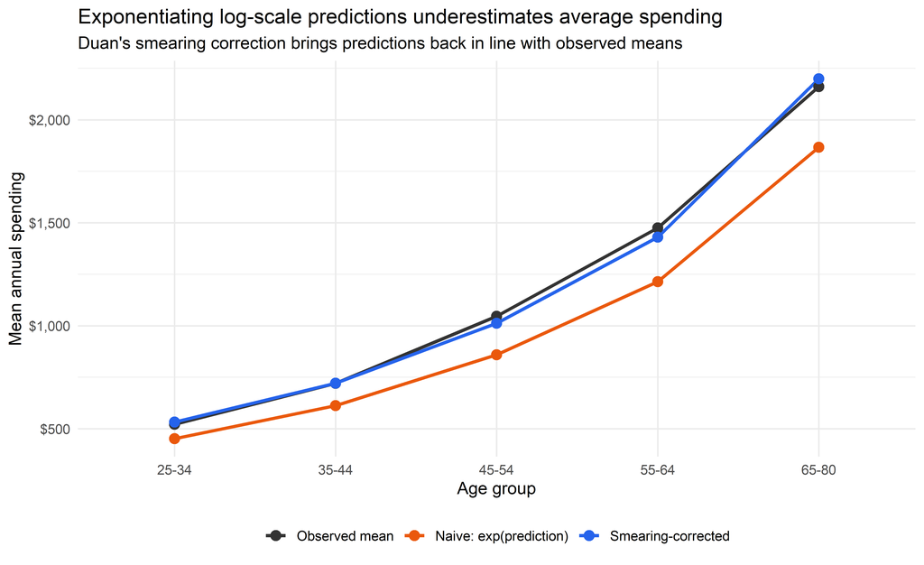

Figure 7: Figure 10. Mean annual spending by age group: observed, naively retransformed from a log model, and smearing-corrected.

```r
ggplot(retrans_df, aes(age_group, mean_spending, color = estimate, group = estimate)) +
  geom_line(linewidth = 1.1) +
  geom_point(size = 3) +
  scale_y_continuous(labels = dollar) +
  scale_color_manual(values = c("Observed mean" = "gray20",
                                "Naive: exp(prediction)" = col_orange,
                                "Smearing-corrected" = col_blue)) +
  labs(title = "Exponentiating log-scale predictions underestimates average spending",
       subtitle = "Duan's smearing correction brings predictions back in line with observed means",
       x = "Age group", y = "Mean annual spending", color = NULL) +
  theme(legend.position = "bottom")
```

Across the whole sample, observed mean spending is $1,282. Exponentiating the model’s predictions gives an average of only $1,087, an underestimate of 15.2%. The smearing factor is 1.178, and the corrected average is $1,280.

Smearing works well here because our simulated errors have the same variance for everyone. When the variance of the log-scale errors differs across groups (for example, if spending among people with chronic conditions is more variable), a single smearing factor is no longer enough, and a log-link GLM is usually the safer choice (Manning, 1998).

Note that this problem concerns *predicting levels*. The *ratio* interpretation of the coefficients, $\exp(\beta)$, is not affected by retransformation bias when the errors have constant variance.

# 5. Hands-on Modeling in R

### 5.1 A logistic regression of chronic disease

We now fit a logistic regression to the simulated survey, using the same predictors that generated the data. Because we simulated the data, we can compare each estimate with its true value.

```r
logit_model <- glm(has_chronic ~ age + log(income) + has_insurance,
                   data = health_df, family = binomial(link = "logit"))

# True values: the DGP used log(income / 1000) = log(income) - log(1000),
# so only the intercept differs from the -4.2 written in the simulation code.
true_vals <- c("(Intercept)"  = -4.2 + 0.45 * log(1000),
               "age"          = 0.055,
               "log(income)"  = -0.45,
               "has_insurance" = -0.3)

or_table <- tidy(logit_model) %>%
  mutate(
    true_beta  = true_vals[term],
    odds_ratio = exp(estimate),
    ci_lower   = exp(estimate - 1.96 * std.error),
    ci_upper   = exp(estimate + 1.96 * std.error)
  ) %>%
  select(term, true_beta, estimate, std.error, odds_ratio, ci_lower, ci_upper, p.value)

or_table %>%
  kbl(digits = 4,
      col.names = c("Term", "True β", "Estimated β (log-odds)", "SE", "Odds ratio exp(β)",
                    "95% CI lower", "95% CI upper", "p-value"),
      caption = "Table 8. Logistic regression of chronic disease: log-odds coefficients and odds ratios") %>%
  kable_styling(bootstrap_options = c("striped", "hover", "condensed"))
```

Table 8. Logistic regression of chronic disease: log-odds coefficients and odds ratios

| Term | True β | Estimated β (log-odds) | SE | Odds ratio exp(β) | 95% CI lower | 95% CI upper | p-value |
| --- | --- | --- | --- | --- | --- | --- | --- |
| (Intercept) | -1.0915 | -0.5443 | 1.8294 | 0.5802 | 0.0161 | 20.9312 | 0.7661 |
| age | 0.0550 | 0.0407 | 0.0070 | 1.0416 | 1.0273 | 1.0560 | 0.0000 |
| log(income) | -0.4500 | -0.4298 | 0.1706 | 0.6506 | 0.4657 | 0.9090 | 0.0118 |
| has_insurance | -0.3000 | -0.2009 | 0.2545 | 0.8180 | 0.4967 | 1.3471 | 0.4299 |

```r
b_age   <- coef(logit_model)[["age"]]
b_inc   <- coef(logit_model)[["log(income)"]]
b_ins   <- coef(logit_model)[["has_insurance"]]

or_age   <- exp(b_age)
or_age10 <- exp(10 * b_age)
or_inc10 <- exp(b_inc * log(1.1))
or_inc2  <- exp(b_inc * log(2))
or_ins   <- exp(b_ins)

pp <- function(a) {
  predict(logit_model,
          newdata = tibble(age = a, income = median(health_df$income), has_insurance = 1),
          type = "response")
}
p30 <- pp(30); p40 <- pp(40); p70 <- pp(70); p80 <- pp(80)

# Does each true slope fall inside its 95% CI (on the log-odds scale)?
coverage <- or_table %>%
  filter(term != "(Intercept)") %>%
  mutate(lo = log(ci_lower), hi = log(ci_upper),
         covered = true_beta >= lo & true_beta <= hi)
age_lo <- coverage$lo[coverage$term == "age"]
age_hi <- coverage$hi[coverage$term == "age"]
```

How well did the model recover the truth? The income and insurance estimates are near their true values, and both true values lie inside the 95% confidence intervals. The age estimate (0.0407) is lower than the true value of 0.055, and the true value falls just outside its 95% interval of [0.027, 0.0545]. This is not a coding error. A 95% interval is built so that, across many repeated samples, about 1 in 20 intervals will miss the true value, and with only 107 cases of chronic disease in a sample of 2,000, an estimate this far from the truth is entirely possible. Rerun the simulation with a different seed and the age estimate will move around 0.055. Simulations like this are a good reminder that a single study gives an estimate, not the truth.

A side note on the intercept: the simulation code wrote income as $\log(\text{income} / 1000)$, while the model uses $\log(\text{income})$. By the quotient rule, $\log(\text{income}/1000) = \log(\text{income}) - \log(1000)$, so rescaling income only shifts the intercept and leaves the slope unchanged. The “True β” column accounts for this.

#### Reading each coefficient

**Age.** The coefficient is 0.0407 on the log-odds scale, so the odds ratio is $\exp(0.0407) = 1.0416$. Each additional year of age multiplies the odds of chronic disease by 1.042, which is a 4.2% increase in the odds. For a 10-year difference, the power rule gives $\exp(10 \times 0.0407) = 1.503$: the odds are 1.5 times as high, or 50% higher. Note that this is *not* $10 \times 4.2\%$, because odds ratios multiply rather than add.

**Income (logged).** Because income enters as $\log(\text{income})$, its coefficient describes the effect of a proportional change in income. A 10% increase in income multiplies the odds by $\exp(-0.43 \times \log 1.1) = 0.96$, a 4% reduction in the odds. Doubling income multiplies the odds by $\exp(-0.43 \times \log 2) = 0.742$.

**Insurance.** The odds ratio for insurance is 0.818. Insured respondents have odds of chronic disease that are 0.82 times those of uninsured respondents with the same age and income. (In this simulation the effect is built in; in real data, an insurance coefficient like this would raise questions about reverse causation and selection, since sick people may seek out insurance.)

#### From odds ratios to probabilities

As Figure 9 showed, the same odds ratio implies different changes in probability depending on the baseline. For an insured person with median income, the model predicts:

| Age change | Predicted probability | Change |
| --- | --- | --- |
| 30 to 40 | 1.7% to 2.6% | 0.9 percentage points |
| 70 to 80 | 8.3% to 12.0% | 3.7 percentage points |

Both rows correspond to the same odds ratio of 1.5, yet the change in probability is several times larger at older ages, where the baseline probability is closer to 50%. When readers care about absolute risk, report predicted probabilities or average marginal effects alongside odds ratios.

#### Why the confidence interval is not symmetric

The confidence limits in Table 8 were computed on the log-odds scale, as $\hat\beta \pm 1.96 \times \text{SE}$, and then exponentiated. An interval that is symmetric on the log scale becomes asymmetric on the ratio scale: the upper limit is farther from the point estimate than the lower limit. Figure 11 shows both scales. To make the age effect visible next to the others, age is shown per 10 years.

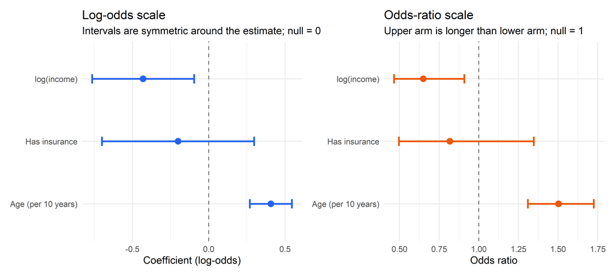

Figure 8: Figure 11. Coefficients and 95% confidence intervals on the log-odds scale (symmetric) and the odds-ratio scale (asymmetric). Age is shown per 10 years.

```r
forest_df <- tidy(logit_model) %>%
  filter(term != "(Intercept)") %>%
  mutate(
    scale_k   = ifelse(term == "age", 10, 1),
    label     = recode(term, age = "Age (per 10 years)", `log(income)` = "log(income)",
                       has_insurance = "Has insurance"),
    est       = estimate * scale_k,
    se        = std.error * scale_k,
    lo        = est - 1.96 * se,
    hi        = est + 1.96 * se
  )

p_forest_log <- ggplot(forest_df, aes(est, label)) +
  geom_vline(xintercept = 0, linetype = "dashed", color = col_gray) +
  geom_errorbarh(aes(xmin = lo, xmax = hi), height = 0.15, color = col_blue, linewidth = 1) +
  geom_point(size = 3, color = col_blue) +
  labs(title = "Log-odds scale", subtitle = "Intervals are symmetric around the estimate; null = 0",
       x = "Coefficient (log-odds)", y = NULL)

p_forest_or <- ggplot(forest_df, aes(exp(est), label)) +
  geom_vline(xintercept = 1, linetype = "dashed", color = col_gray) +
  geom_errorbarh(aes(xmin = exp(lo), xmax = exp(hi)), height = 0.15, color = col_orange, linewidth = 1) +
  geom_point(size = 3, color = col_orange) +
  labs(title = "Odds-ratio scale", subtitle = "Upper arm is longer than lower arm; null = 1",
       x = "Odds ratio", y = NULL)

p_forest_log + p_forest_or
```

A good habit: when plotting odds ratios, use a log axis (`scale_x_log10()`). The intervals then look symmetric again, and an odds ratio of 0.5 sits the same distance from 1 as an odds ratio of 2, which matches their meaning (halving vs. doubling the odds).

### 5.2 A property of logistic regression that surprises many researchers

In linear regression, leaving out a predictor that is unrelated to $X$ does not change the coefficient on $X$; it only makes the estimate less precise. In logistic regression, this is **not** true. Leaving out a predictor that affects the outcome changes the coefficient on $X$, *even if the omitted predictor is completely independent of $X$*. This property is called **non-collapsibility** of the odds ratio.

The reason is that the logistic model has no separate error term to absorb the omitted variable. Its variance is fixed by the logistic distribution, so leaving out a predictor that explains part of the outcome effectively rescales all remaining coefficients toward zero. A large simulation makes the point clearly.

```r
set.seed(99)
n_big <- 100000

nc_df <- tibble(
  x = rnorm(n_big),
  z = rbinom(n_big, 1, 0.5)          # z is independent of x
) %>%
  mutate(
    y_cont = 0.5 * x + 2 * z + rnorm(n_big),
    y_bin  = rbinom(n_big, 1, plogis(-1 + 0.5 * x + 2 * z))
  )

tibble(
  model = c("Linear: y ~ x + z", "Linear: y ~ x (z omitted)",
            "Logistic: y ~ x + z", "Logistic: y ~ x (z omitted)"),
  true_beta = 0.5,
  estimate = c(
    coef(lm(y_cont ~ x + z, data = nc_df))[["x"]],
    coef(lm(y_cont ~ x, data = nc_df))[["x"]],
    coef(glm(y_bin ~ x + z, family = binomial, data = nc_df))[["x"]],
    coef(glm(y_bin ~ x, family = binomial, data = nc_df))[["x"]]
  )
) %>%
  kbl(digits = 3,
      col.names = c("Model", "True coefficient on x", "Estimated coefficient on x"),
      caption = "Table 9. Omitting an independent predictor: linear vs. logistic regression (n = 100,000)") %>%
  kable_styling(bootstrap_options = c("striped", "hover", "condensed"), full_width = FALSE)
```

Table 9. Omitting an independent predictor: linear vs. logistic regression (n = 100,000)

| Model | True coefficient on x | Estimated coefficient on x |
| --- | --- | --- |
| Linear: y ~ x + z | 0.5 | 0.495 |
| Linear: y ~ x (z omitted) | 0.5 | 0.497 |
| Logistic: y ~ x + z | 0.5 | 0.514 |
| Logistic: y ~ x (z omitted) | 0.5 | 0.411 |

In the linear model, dropping $z$ leaves the coefficient on $x$ at about 0.5. In the logistic model, dropping $z$ shrinks it noticeably, even though $z$ is unrelated to $x$. This has practical consequences (Mood, 2010):

- Odds ratios from models with different sets of control variables are not directly comparable, even when the added controls are not confounders.
- Comparing odds ratios across groups (for example, men and women) can be misleading if the amount of unexplained variation differs between groups.
- Predicted probabilities and average marginal effects are much less affected, which is one more reason to report them.

### 5.3 A log-linear model of healthcare spending

Finally, we fit the spending model from Section 4 and translate its coefficients.

```r
spend_tbl <- tidy(spend_lm) %>%
  filter(term != "(Intercept)") %>%
  mutate(
    approx_pct  = estimate * 100,
    exact_ratio = exp(estimate),
    exact_pct   = (exp(estimate) - 1) * 100
  )

b_sp_age <- spend_tbl$estimate[spend_tbl$term == "age"]
b_sp_chr <- spend_tbl$estimate[spend_tbl$term == "has_chronic"]

spend_tbl %>%
  select(term, estimate, std.error, approx_pct, exact_ratio, exact_pct) %>%
  kbl(digits = c(0, 4, 4, 1, 3, 1),
      col.names = c("Term", "β (log scale)", "SE", "Shortcut: β × 100 (%)",
                    "Ratio exp(β)", "Exact: [exp(β) - 1] × 100 (%)"),
      caption = "Table 10. Log-linear model of annual spending: shortcut vs. exact interpretation") %>%
  kable_styling(bootstrap_options = c("striped", "hover", "condensed"), full_width = FALSE)
```

Table 10. Log-linear model of annual spending: shortcut vs. exact interpretation

| Term | β (log scale) | SE | Shortcut: β × 100 (%) | Ratio exp(β) | Exact: [exp(β) - 1] × 100 (%) |
| --- | --- | --- | --- | --- | --- |
| age | 0.0313 | 0.0008 | 3.1 | 1.032 | 3.2 |
| has_chronic | 0.7834 | 0.0569 | 78.3 | 2.189 | 118.9 |

Table 10 puts the lesson of Section 3.2 into practice:

- **Age** has a small coefficient (0.0313), so the shortcut and the exact calculation agree: each additional year of age goes with about 3.2% higher spending. Over 10 years, spending is multiplied by $\exp(10 \times 0.0313) = 1.37$.
- **Chronic disease** has a large coefficient (0.783). The shortcut would say spending is 78% higher, but the exact figure is 119% higher: people with a chronic condition spend 2.19 times as much, holding age constant. Using the shortcut here would understate the gap substantially.

Strictly speaking, $\exp(\beta)$ in a log-linear model is a ratio of *geometric* means (or medians, if the errors are symmetric). When the error variance is constant, it is also the ratio of arithmetic means.

# 6. Visualizing the Transformation Journey

Figure 12 follows a single model through all of its scales. Panels 1 to 3 show the predicted risk of chronic disease by age for an insured person with median income, expressed as a probability, as odds, and as log-odds. Panel 4 shows the raw spending data on a log axis.

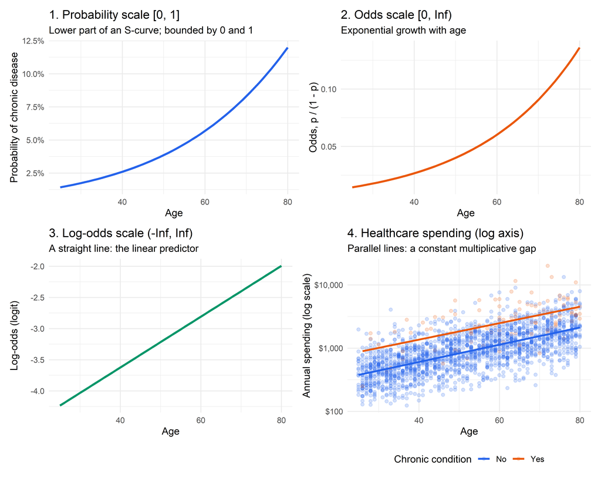

Figure 12. One logistic model seen on three scales (panels 1-3), and healthcare spending on a log axis (panel 4).

```r
pred_grid <- tibble(
  age           = 25:80,
  income        = median(health_df$income),
  has_insurance = 1
)

pred_grid <- pred_grid %>%
  mutate(
    log_odds = predict(logit_model, newdata = pred_grid, type = "link"),
    odds     = exp(log_odds),
    prob     = predict(logit_model, newdata = pred_grid, type = "response")
  )

p_prob <- ggplot(pred_grid, aes(x = age, y = prob)) +
  geom_line(color = col_blue, linewidth = 1.2) +
  scale_y_continuous(labels = percent_format()) +
  labs(title = "1. Probability scale [0, 1]", subtitle = "Lower part of an S-curve; bounded by 0 and 1",
       x = "Age", y = "Probability of chronic disease")

p_odds <- ggplot(pred_grid, aes(x = age, y = odds)) +
  geom_line(color = col_orange, linewidth = 1.2) +
  labs(title = "2. Odds scale [0, Inf)", subtitle = "Exponential growth with age",
       x = "Age", y = "Odds, p / (1 - p)")

p_log_odds <- ggplot(pred_grid, aes(x = age, y = log_odds)) +
  geom_line(color = col_green, linewidth = 1.2) +
  labs(title = "3. Log-odds scale (-Inf, Inf)", subtitle = "A straight line: the linear predictor",
       x = "Age", y = "Log-odds (logit)")

p_spending <- ggplot(health_df, aes(x = age, y = annual_spending, color = factor(has_chronic))) +
  geom_point(alpha = 0.2) +
  geom_smooth(method = "lm", se = FALSE, linewidth = 1.1) +
  scale_y_log10(labels = dollar_format()) +
  scale_color_manual(values = c("0" = col_blue, "1" = col_orange), labels = c("No", "Yes")) +
  labs(title = "4. Healthcare spending (log axis)", subtitle = "Parallel lines: a constant multiplicative gap",
       x = "Age", y = "Annual spending (log scale)", color = "Chronic condition") +
  theme(legend.position = "bottom")

(p_prob + p_odds) / (p_log_odds + p_spending)
```

How to read Figure 12:

1. **Probability scale.** The predicted probability rises with age along the lower part of an S-curve. It can approach but never cross 0 or 1. Because the slope changes with age, there is no single number that summarizes “the effect of age” on this scale.
2. **Odds scale.** The same predictions expressed as odds grow exponentially with age. Each year multiplies the odds by the same factor, 1.042, so the curve bends upward. Panels 1 and 2 look almost identical here because the predicted probability stays below about 12%. When an outcome is this rare, odds and probabilities are nearly equal, a point that matters for interpreting odds ratios (Section 7).
3. **Log-odds scale.** Taking the log of panel 2 straightens the curve. This is the scale on which the model is linear and on which the coefficient 0.0407 is the constant slope. Note that the model is estimated by maximum likelihood, not by ordinary least squares; the straight line is the linear predictor, not an OLS fit.
4. **Spending on a log axis.** The two groups form parallel bands. On a log axis, parallel means the vertical distance between them is constant, which means the *ratio* of spending between groups is constant across ages: about 2.19 at every age.

Panels 2 and 3 are the same relationship seen through the two lenses of this post: $\exp$ takes panel 3 to panel 2, and $\log$ takes panel 2 back to panel 3.

# 7. Applied Social Scientist’s Cheat Sheet

| Model | Formula | Meaning of $\beta_1$ | Reporting template | Common mistake |
| --- | --- | --- | --- | --- |
| **Linear-linear** | $Y = \beta_0 + \beta_1 X$ | A 1-unit increase in $X$ goes with a $\beta_1$-unit change in $Y$. | *“Each additional year of schooling is associated with a $\beta_1$-point higher self-rated health score.”* | Few; but check whether the relationship is really linear. |
| **Log-linear** | $\log Y = \beta_0 + \beta_1 X$ | A 1-unit increase in $X$ multiplies $Y$ by $\exp(\beta_1)$, a $(\exp(\beta_1) - 1) \times 100\%$ change. | *“Each additional year of age is associated with $[(\exp(\beta_1) - 1) \times 100]\%$ higher medical spending.”* | Reading $\beta_1 \times 100\%$ when $\lvert\beta_1\rvert > 0.1$; exponentiating predictions without a retransformation correction. |
| **Linear-log** | $Y = \beta_0 + \beta_1 \log X$ | A 1% increase in $X$ goes with about a $\beta_1 / 100$-unit change in $Y$. Exactly, multiplying $X$ by $k$ changes $Y$ by $\beta_1 \log k$. | *“A 10% increase in county median income is associated with $\beta_1 \times \log(1.10) \approx 0.095\beta_1$ more years of life expectancy.”* | Reading $\beta_1$ as the effect of a 1% (rather than a 1-log-unit) change. |
| **Log-log** | $\log Y = \beta_0 + \beta_1 \log X$ | A 1% increase in $X$ goes with about a $\beta_1\%$ change in $Y$ (an elasticity). | *“A 1% increase in cigarette prices is associated with a $\lvert\beta_1\rvert\%$ decrease in consumption.”* | Confusing percent change with percentage-point change. |
| **Logistic** | $\log\frac{p}{1-p} = \beta_0 + \beta_1 X$ | A 1-unit increase in $X$ multiplies the *odds* by $\exp(\beta_1)$. | *“Insured respondents had $\exp(\beta_1)$ times the odds of receiving a cancer screening compared with uninsured respondents.”* | Reading the OR as a risk ratio; comparing ORs across models with different controls. |
| **Poisson / Cox (log link)** | $\log \lambda = \beta_0 + \beta_1 X$ | A 1-unit increase in $X$ multiplies the *rate* or *hazard* by $\exp(\beta_1)$. | *“Each additional year of age is associated with a $[(\exp(\beta_1) - 1) \times 100]\%$ higher mortality rate.”* | Forgetting the exposure (offset) term in rate models. |

**TipPercent change vs. percentage-point change**

If a smoking rate falls from 20% to 15%, it has fallen by **5 percentage points**, which is a **25% decrease** relative to the starting value. Log models describe percent (relative) changes; linear probability models describe percentage-point (absolute) changes. Always say which one you mean.

### The odds ratio is not the risk ratio

The **risk ratio (RR)**, also called the relative risk, compares probabilities: $\text{RR} = p_1 / p_0$. The **odds ratio** compares odds. When the outcome is rare, odds and probabilities are nearly the same ($p / (1 - p) \approx p$ when $p$ is small), so OR $\approx$ RR. When the outcome is common, the OR is farther from 1 than the RR, and reading an OR as “times the risk” exaggerates the effect.

If the baseline probability in the reference group is $p_0$, the RR implied by a given OR is (Zhang & Yu, 1998)

$$\text{RR} = \frac{\text{OR}}{1 - p_0 + p_0 \times \text{OR}}.$$

For example, with $p_0 = 0.4$ (roughly the prevalence of adult obesity in the United States) and OR $= 2$, the risk ratio is only $2 / 1.4 \approx 1.43$. Figure 13 shows the pattern across baseline probabilities. (This formula is a useful guide for interpretation; for formal estimation of risk ratios with covariates, methods such as log-binomial or modified Poisson regression are preferred.)

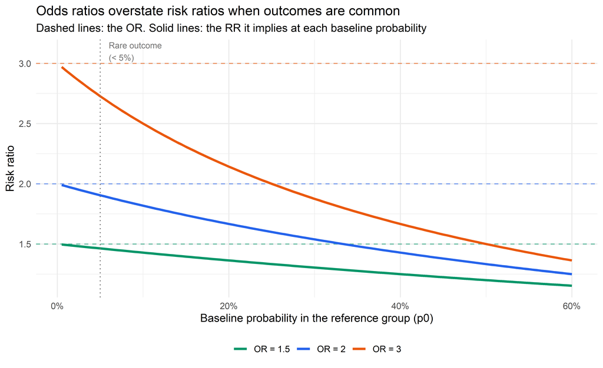

Figure 9: Figure 13. The risk ratio implied by a fixed odds ratio, as a function of the baseline probability in the reference group.

```r
orrr_df <- expand_grid(p0 = seq(0.005, 0.6, by = 0.005), OR = c(1.5, 2, 3)) %>%
  mutate(RR = OR / (1 - p0 + p0 * OR),
         OR_label = paste0("OR = ", OR))

or_ref <- tibble(OR = c(1.5, 2, 3), OR_label = paste0("OR = ", c(1.5, 2, 3)))

ggplot(orrr_df, aes(p0, RR, color = OR_label)) +
  geom_hline(data = or_ref, aes(yintercept = OR, color = OR_label), linetype = "dashed", alpha = 0.6) +
  geom_line(linewidth = 1.2) +
  geom_vline(xintercept = 0.05, linetype = "dotted", color = col_gray) +
  annotate("text", x = 0.06, y = 3.1, label = "Rare outcome\n(< 5%)", hjust = 0, size = 3.2, color = col_gray) +
  scale_x_continuous(labels = percent) +
  scale_color_manual(values = c("OR = 1.5" = col_green, "OR = 2" = col_blue, "OR = 3" = col_orange)) +
  labs(title = "Odds ratios overstate risk ratios when outcomes are common",
       subtitle = "Dashed lines: the OR. Solid lines: the RR it implies at each baseline probability",
       x = "Baseline probability in the reference group (p0)", y = "Risk ratio",
       color = NULL) +
  theme(legend.position = "bottom")
```

When the baseline probability is below about 5%, each solid line stays close to its dashed line, and the OR is a reasonable stand-in for the RR. As the baseline probability rises, the gap widens quickly.

### R and Stata equivalents

| Task | R | Stata |
| --- | --- | --- |
| Natural log / base-10 log | `log(x)` / `log10(x)` | `ln(x)` or `log(x)` / `log10(x)` |
| Exponential | `exp(x)` | `exp(x)` |
| Geometric mean | `exp(mean(log(x)))` | `ameans x` |
| Odds ratios with 95% CI | `broom::tidy(m, exponentiate = TRUE, conf.int = TRUE)` | `logit y x, or` or `logistic y x` |
| Predicted probabilities | `predict(m, type = "response")` | `predict p, pr` or `margins` |
| Average marginal effects | `marginaleffects::avg_slopes(m)` | `margins, dydx(*)` |
| Log-link GLM for spending | `glm(y ~ x, family = Gamma(link = "log"))` | `glm y x, family(gamma) link(log)` |
| Rate ratios with exposure | `glm(y ~ x + offset(log(pop)), family = poisson)`, then `exp(coef(m))` | `poisson y x, exposure(pop) irr` |

# 8. Conclusion

The constant $e$ and the functions $\log$ and $\exp$ are not arbitrary hurdles. They are the tools that let **additive statistical models** describe a **multiplicative world**: compounding infections, mortality that doubles every few years of adult age, and income whose effects depend on proportions rather than dollars.

```
      MULTIPLICATIVE WORLD                        ADDITIVE WORLD
  (ratios, growth, odds, rates)              (differences, straight lines)

    Y grows by a constant ratio   --- log --->   log Y grows by a constant amount
    Odds are multiplied by OR     --- log --->   log-odds increase by beta
    Geometric mean                <--- exp ---   Arithmetic mean of logs
    Odds ratio = exp(beta)        <--- exp ---   Coefficient beta
```

Whenever you meet a log or an exponential in your research, ask four questions:

1. **Which world am I in?** Is this number a difference (additive world) or a ratio (multiplicative world)?
2. **Is the shortcut safe?** Read $\beta \times 100\%$ only when $|\beta| < 0.1$; otherwise compute $\exp(\beta) - 1$.
3. **Ratio of what?** An odds ratio is not a risk ratio, and neither is a change in probability. A ratio of geometric means is not a ratio of totals.
4. **What could go wrong?** Zeros in the outcome, retransformation bias when predicting levels, and non-collapsibility when comparing odds ratios across models.

With these questions in hand, logistic regression coefficients, log-income models, and Gompertz mortality curves become variations on a single idea: logs turn multiplication into addition, and exp turns it back.

# References

- Duan, N. (1983). Smearing estimate: A nonparametric retransformation method. *Journal of the American Statistical Association*, 78(383), 605-610.
- Gompertz, B. (1825). On the nature of the function expressive of the law of human mortality, and on a new mode of determining the value of life contingencies. *Philosophical Transactions of the Royal Society of London*, 115, 513-583.
- Manning, W. G. (1998). The logged dependent variable, heteroscedasticity, and the retransformation problem. *Journal of Health Economics*, 17(3), 283-295.
- Maor, E. (1994). *e: The Story of a Number*. Princeton University Press.
- Mood, C. (2010). Logistic regression: Why we cannot do what we think we can do, and what we can do about it. *European Sociological Review*, 26(1), 67-82.
- Preston, S. H. (1975). The changing relation between mortality and level of economic development. *Population Studies*, 29(2), 231-248.
- Zhang, J., & Yu, K. F. (1998). What’s the relative risk? A method of correcting the odds ratio in cohort studies of common outcomes. *JAMA*, 280(19), 1690-1691.